# Creating `ggplot2` Graphics

Colleen Yancey

April 11, 2018

### Overview

Today I will be making some nice graphs for of my Honor’s Thesis Data. We have done a bunch of work in ggplot the last few days and it will help me to make some good graphs that will be of publishable quality.

### Onto Graphing

```r
# Call Libraries
library(ggplot2)
library(ggthemes)
library(patchwork)
library(RColorBrewer)
```

```r
Hdata <- read.table("MasterListR.csv",header=TRUE,sep=",", stringsAsFactors=FALSE)
str(Hdata)
```

```
## 'data.frame':    60 obs. of  6 variables:
##  $ Plot.ID  : int  1 1 1 2 2 2 3 3 3 4 ...
##  $ Subplot  : int  2 3 6 2 3 6 2 3 6 2 ...
##  $ Treatment: chr  "12.7x2" "12.7x2" "12.7x2" "12.7" ...
##  $ ECM      : num  1.05 1.15 1.05 1.46 1.36 ...
##  $ AMF      : num  3.5 4.14 3.22 5.8 NA ...
##  $ Season   : chr  "Spring" "Spring" "Spring" "Spring" ...
```

```r
summary(Hdata)
```

```
##     Plot.ID        Subplot       Treatment              ECM
##  Min.   : 1.0   Min.   :2.000   Length:60          Min.   :0.4464
##  1st Qu.: 3.0   1st Qu.:2.000   Class :character   1st Qu.:0.8000
##  Median : 5.5   Median :3.000   Mode  :character   Median :1.0547
##  Mean   : 5.5   Mean   :3.667                      Mean   :1.1048
##  3rd Qu.: 8.0   3rd Qu.:6.000                      3rd Qu.:1.3387
##  Max.   :10.0   Max.   :6.000                      Max.   :2.1870
##
##       AMF           Season
##  Min.   : 3.00   Length:60
##  1st Qu.: 6.25   Class :character
##  Median :10.70   Mode  :character
##  Mean   :12.56
##  3rd Qu.:17.30
##  Max.   :30.91
##  NA's   :12
```

```r
level_order <-c("0", "6.4", "12.7", "19", "12.7x2")
```

```r
# subset the data to make it easier to work on
# subset spring data
SpringData <- Hdata[1:30,]
print(SpringData)
```

```
##    Plot.ID Subplot Treatment       ECM       AMF Season
## 1        1       2    12.7x2 1.0500000  3.500000 Spring
## 2        1       3    12.7x2 1.1500000  4.142857 Spring
## 3        1       6    12.7x2 1.0458262  3.222222 Spring
## 4        2       2      12.7 1.4593569  5.800000 Spring
## 5        2       3      12.7 1.3602975        NA Spring
## 6        2       6      12.7 1.3051788  6.430000 Spring
## 7        3       2       6.4 1.2105974        NA Spring
## 8        3       3       6.4 0.9145167  7.058824 Spring
## 9        3       6       6.4 0.7764729  8.000000 Spring
## 10       4       2         0 1.8092910  7.333333 Spring
## 11       4       3         0 1.8948574  7.200000 Spring
## 12       4       6         0 2.1870394  8.923077 Spring
## 13       5       2        19 1.5254404        NA Spring
## 14       5       3        19 1.7119216  3.000000 Spring
```

[output cut: 16 more lines]

```r
#subset fall data
FallData <- Hdata[31:60,]
print(FallData)
```

```
##    Plot.ID Subplot Treatment       ECM      AMF Season
## 31       1       2    12.7x2 1.0000000 17.00000   Fall
## 32       1       3    12.7x2 1.2000000 29.00000   Fall
## 33       1       6    12.7x2 1.1000000 16.60000   Fall
## 34       2       2      12.7 0.8000000 21.50000   Fall
## 35       2       3      12.7 0.8000000 19.80000   Fall
## 36       2       6      12.7 0.6500000       NA   Fall
## 37       3       2       6.4 0.5000000 17.20000   Fall
## 38       3       3       6.4 0.5833333 11.60000   Fall
## 39       3       6       6.4 0.8000000       NA   Fall
## 40       4       2         0 1.1107355 18.50000   Fall
## 41       4       3         0 1.8000000 17.60000   Fall
## 42       4       6         0 1.0688519 15.00000   Fall
## 43       5       2        19 0.4463923 10.72727   Fall
## 44       5       3        19 0.7109847 15.75000   Fall
```

[output cut: 16 more lines]

### Making Box Plots of Data Seasonally

```r
# Below will make Spring ECM and AMF colonization box plots
#ECM data below
ESplot<- ggplot(data=SpringData, mapping=aes(x=factor(Treatment, level=level_order), y=ECM, fill=Treatment)) +
  geom_boxplot() +
  theme_base(base_size=14) +
  xlab("Icing Treatment(mm of ice)") +
  ylab("ECM COlonization (tips/cm)")+
  ggtitle("Spring ECM Colonization")+
  ylim(0,3) +
  scale_fill_brewer(palette="Spectral") +
  scale_fill_discrete(name="Ice Treatment",
                         breaks=c("0", "6.4", "12.7", "19", "12.7x2"),
                         labels=c("Control", "Light", "Moderate", "Extreme", "Moderate x2"))
```

```
## which will replace the existing scale.
```

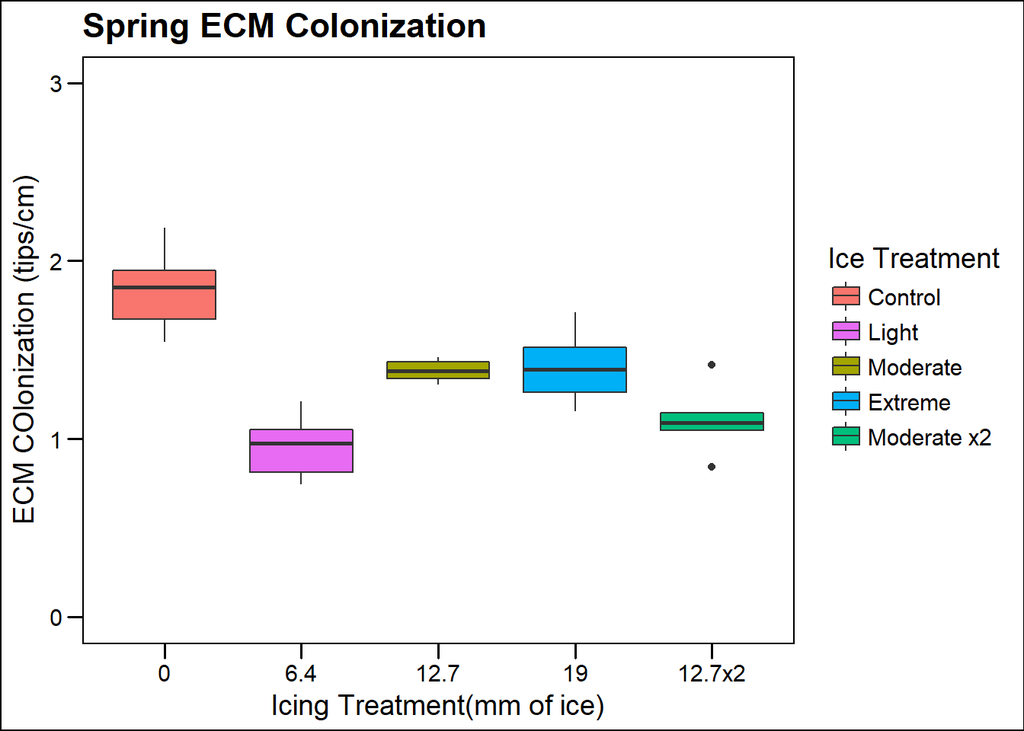

```r
print(ESplot)
```

```r
#AMF data Below
ASplot<- ggplot(data=SpringData, mapping=aes(x=factor(Treatment, level=level_order), y=AMF, fill=Treatment)) +
  geom_boxplot() +
  theme_base(base_size=14) +
  xlab("Icing Treatment(mm of ice)") +
  ylab("AMF COlonization (structures/cm)")+
  ggtitle("Spring AMF Colonization") +
  scale_fill_brewer(palette="Spectral") +
  scale_fill_discrete(name="Ice Treatment",
                         breaks=c("0", "6.4", "12.7", "19", "12.7x2"),
                         labels=c("Control", "Light", "Moderate", "Extreme", "Moderate x2"))
```

```
## which will replace the existing scale.
```

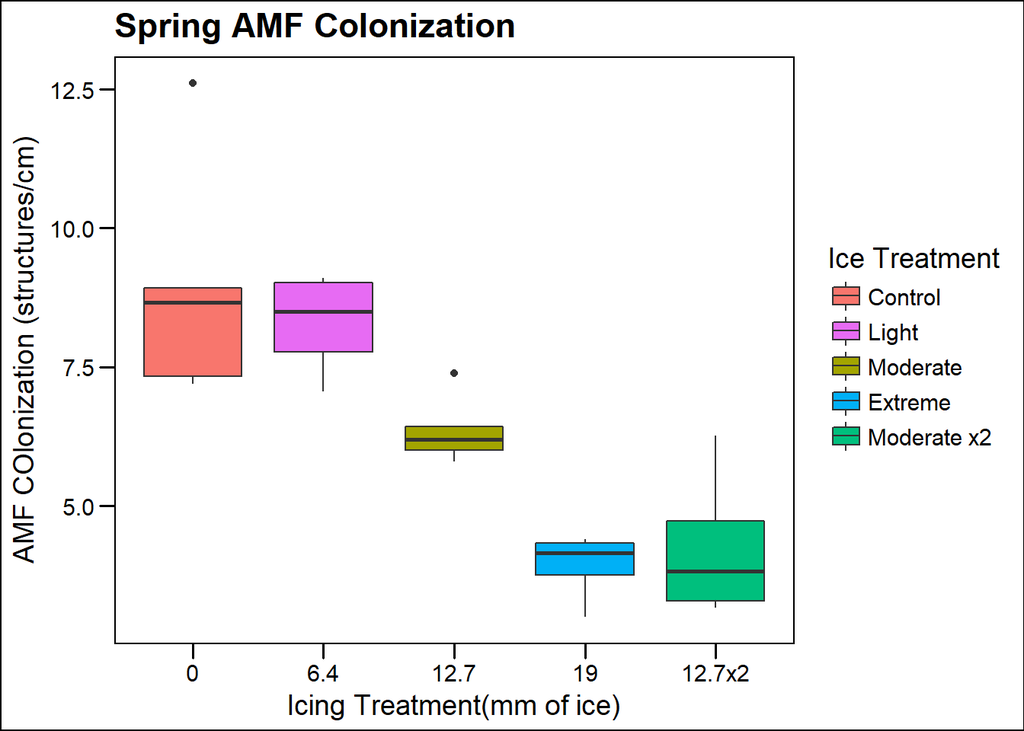

```r
print(ASplot)
```

Now lets Patchwork these together:

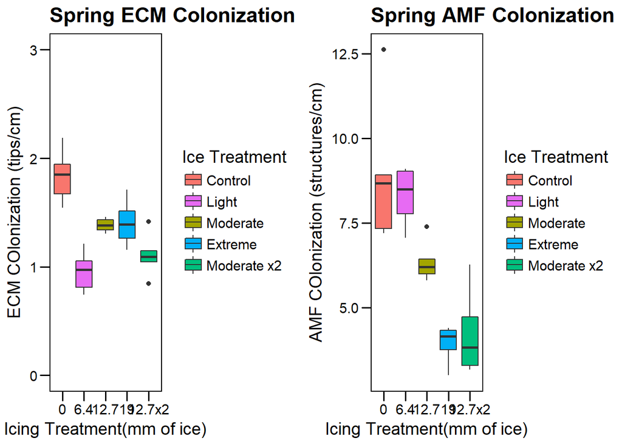

```r
ESplot+ASplot
```

Now I am going to try to plot the 2 together using different dimensions on a dot plot. I don’t know if this will actually be a useful tool to look at thing but it will show BOTH ECM and AMF on 1 graph to see what it looks like according to treatment.

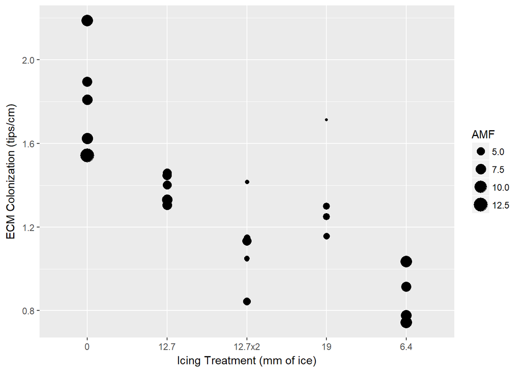

```r
m1 <- ggplot(data=SpringData,
             mapping=(aes(x=Treatment, y=ECM, size=AMF)))+
  geom_point() +
  xlab("Icing Treatment (mm of ice)") +
  ylab("ECM Colonization (tips/cm)")
print(m1)
```

This graph looks cool although I am not sure that I can really use it for anything. It shows you both the relationship of ECM and AMF colonization per sample, but these are 2 independent results. It is cool to see but I don’t think that it will add any extra insight or illustrate my variables any better.  
Next I am going to make graphs for the fall. I could just copy the Spring boxplots but I think that would be pretty boring. I would obviously try to do it for my publication, but want to try my hand at working with other graphs. I think I will work with point graphs for the Fall data just to see what else I can do.

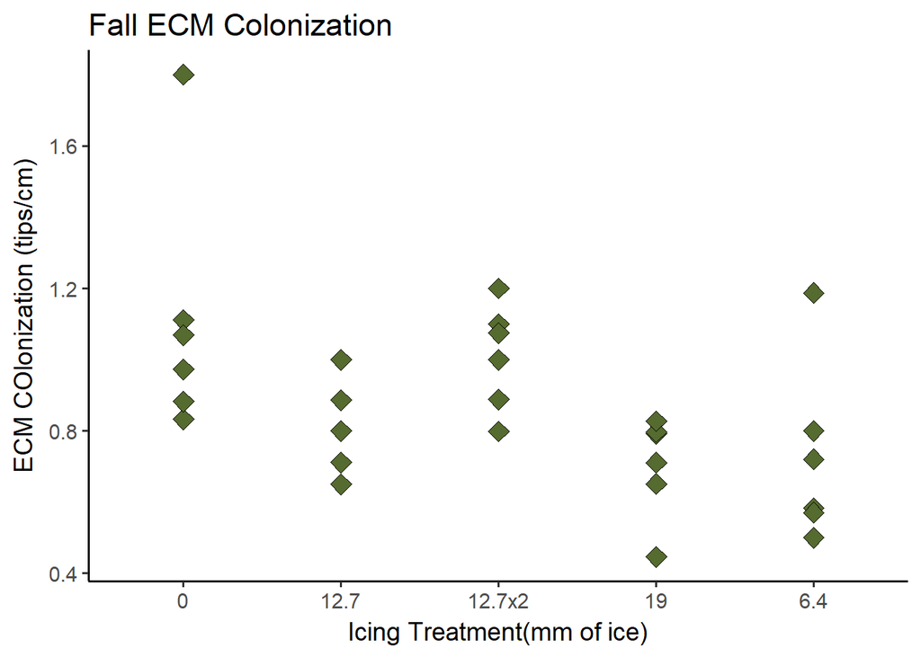

```r
# Below will make Fall ECM and AMF colonization point plots
#ECM data below
EFplot<- ggplot(data=FallData, mapping=aes(x=Treatment, y=ECM)) +
  geom_point(size=4, shape=23, color="black", fill="darkolivegreen") +
  theme_classic(base_size=14) +
  xlab("Icing Treatment(mm of ice)") +
  ylab("ECM COlonization (tips/cm)")+
  ggtitle("Fall ECM Colonization")
print(EFplot)
```

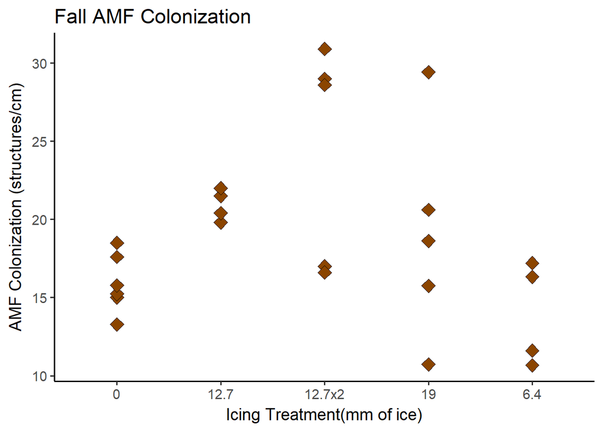

```r
#AMF data Below
AFplot<- ggplot(data=FallData, mapping=aes(x=Treatment, y=AMF)) +
  geom_point(size=4, shape=23, color="black", fill="darkorange4") +
  theme_classic(base_size=14) +
  xlab("Icing Treatment(mm of ice)") +
  ylab("AMF Colonization (structures/cm)")+
  ggtitle("Fall AMF Colonization")
print(AFplot)
```

I think it would be useful to have a side by side comparison of ECM and AMF data seasonally so I can also make that. For this purpose I will make the Fall plots into boxplots so that they are easily compared. I will also add a y limit onto the graphs so that they can be directly visually compared once patchworked together.

```r
#making boxplots of fall data
#ECM data below
EFplot<- ggplot(data=FallData, mapping=aes(x=factor(Treatment, levels=level_order), y=ECM, fill=Treatment)) +
  geom_boxplot() +
  theme_base(base_size=14) +
  xlab("Icing Treatment(mm of ice)") +
  ylab("ECM COlonization (tips/cm)")+
  ggtitle("Fall ECM Colonization")+
  ylim(0,3) +
  scale_fill_brewer(palette="Spectral") +
  scale_fill_discrete(name="Ice Treatment",
                         breaks=c("0", "6.4", "12.7", "19", "12.7x2"),
                         labels=c("Control", "Light", "Moderate", "Extreme", "Moderate x2"))
```

```
## which will replace the existing scale.
```

```r
#AMF data Below
AFplot<- ggplot(data=FallData, mapping=aes(x=factor(Treatment, levels=level_order), y=AMF, fill=Treatment)) +
  geom_boxplot() +
  theme_base(base_size=14) +
  xlab("Icing Treatment(mm of ice)") +
  ylab("AMF Colonization (structures/cm)")+
  ggtitle("Fall AMF Colonization")+
  ylim(0,40) +
  scale_fill_brewer(palette="Spectral") +
  scale_fill_discrete(name="Ice Treatment",
                         breaks=c("0", "6.4", "12.7", "19", "12.7x2"),
                         labels=c("Control", "Light", "Moderate", "Extreme", "Moderate x2"))
```

```
## which will replace the existing scale.
```

```r
#AMF data from spring, adding y lim
ASplot<- ggplot(data=SpringData, mapping=aes(x=factor(Treatment, levels=level_order), y=AMF, fill=Treatment)) +
  geom_boxplot() +
  theme_base(base_size=14) +
  xlab("Icing Treatment(mm of ice)") +
  ylab("AMF COlonization (structures/cm)")+
  ggtitle("Spring AMF Colonization")+
  ylim(0,40)+
  scale_fill_brewer(palette="Spectral") +
  scale_fill_discrete(name="Ice Treatment",
                         breaks=c("0", "6.4", "12.7", "19", "12.7x2"),
                         labels=c("Control", "Light", "Moderate", "Extreme", "Moderate x2"))
```

```
## which will replace the existing scale.
```

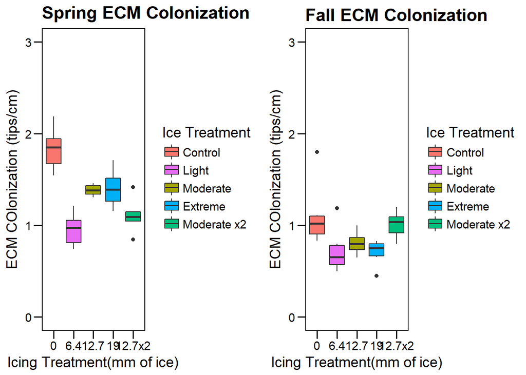

```r
ESplot+EFplot
```

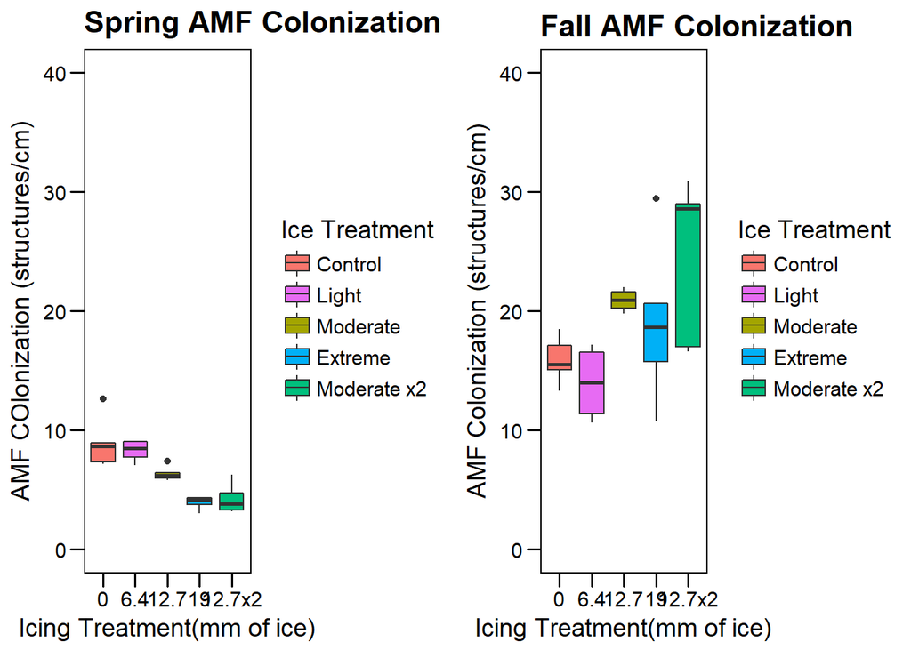

```r
ASplot+AFplot
```

```r
ggsave(filename="ECM.jpg", plot=ESplot+EFplot,
       device="jpg", width=30, height=16, units="cm",
       dpi=300)
ggsave(filename="AMF.jpg", plot=ASplot+AFplot,
       device="jpg", width=30, height=16, units="cm",
       dpi=300)
```

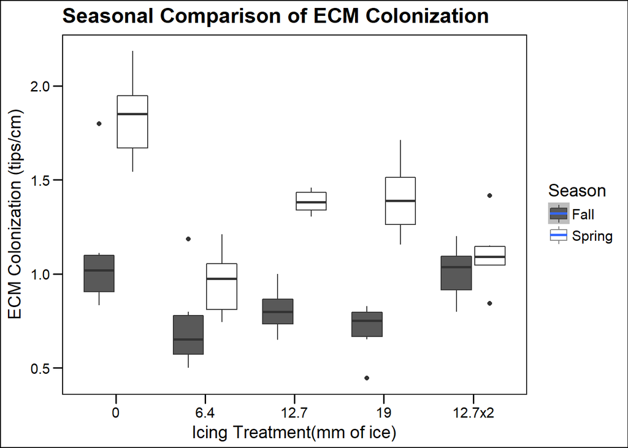

```r
#For ECM data
C <- ggplot(data=Hdata,
             mapping=(aes(x=factor(Treatment, levels=level_order), y=ECM, fill=Season)))+
  geom_boxplot()+
  geom_smooth(method="lm")+
  xlab("Icing Treatment(mm of ice)") +
  ylab("ECM Colonization (tips/cm)")+
  ggtitle("Seasonal Comparison of ECM Colonization")+
  scale_fill_manual(values=c("gray35", "gray100")) +
  theme_base(base_size=14)
print(C)
```

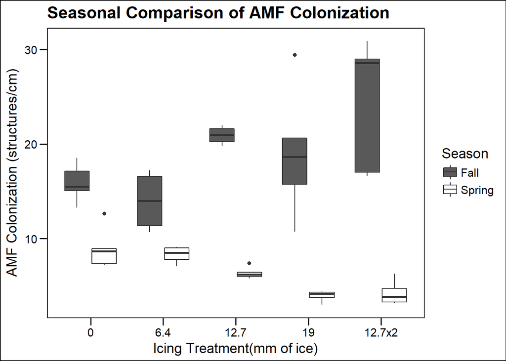

```r
#for AMF data
D <- ggplot(data=Hdata,
             mapping=(aes(x=factor(Treatment, levels=level_order), y=AMF, fill=Season)))+
  geom_boxplot()+
  xlab("Icing Treatment(mm of ice)") +
  ylab("AMF Colonization (structures/cm)")+
  ggtitle("Seasonal Comparison of AMF Colonization")+
  theme_base(base_size=14) +
  scale_fill_manual(values=c("gray35", "gray100"))

print(D)
```

```r
ggsave(filename="SeasonalECM.jpg", plot=D+C,
       device="jpg", width=30, height=16, units="cm",
       dpi=300)
```

The last thing I am going to do is mess around with the colors of the filled boxplots. It seems pretty easy, and is something you can do manually or with color brewer.

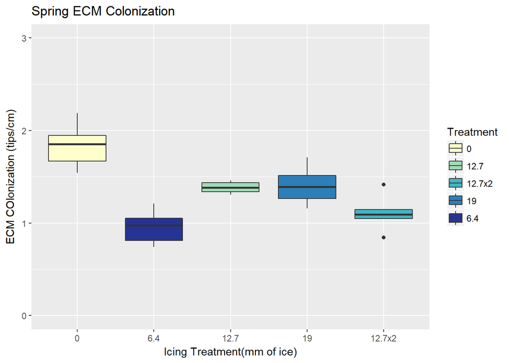

```r
# I am just going to do this on 1 graph, ECM spring data
ESplot<- ggplot(data=SpringData, mapping=aes(x=factor(Treatment, levels=level_order), y=ECM, fill=Treatment)) +
  geom_boxplot()+
  xlab("Icing Treatment(mm of ice)") +
  ylab("ECM COlonization (tips/cm)")+
  ggtitle("Spring ECM Colonization")+
  ylim(0,3) +
  scale_fill_brewer(palette="YlGnBu")
print(ESplot)
```